# CAOS-9 fork

## Prelude: будет много теории

Сегодня мы с вами поговорим про потоки и процессы в Linux (Unix-like OS)

Теории и правда будет много))

Но задачки простые

## Intro

Для начала давайте пофантазируем, что такое процесс. (Сейчас пока без привязки к конкретной ОСи)

(я надеюсь) интуитивно кажется, что это какая-то 'штука' внутри ядря, которая позволяет исполнять код

Есть идеи, что нам нужно, чтоб исполнить код?

Прям по пунктам:

1. ...
2. ...
3. ...

...

## Хто я? (с) Процесс

Ну теперь можем перейти к формальному определению)

Процесс - программа в состоянии выполнения. Он включает в себя:

1. Исполняемый код (section .text)
2. Открытые файлы
3. Сигналы, ожидающие обработки
4. Внутренние данные ядра (об этом позже)
5. Состояние процессора (регистры)
6. Адресное пространство, в которое отображены один или несколько файлов (mmap)
7. Один или несколько потоков выполнения (на самом деле это стек)
8. Сегмент данных с глобальными переменными (section .data / .rodata / .bss)

Кокнуло?)

### 1. Процесс - Исполняемый код

Чтобы что-то исполнять, нам нужно это что-то (вода мокрая, небо голубое, щеночки милые...)

Этим 'чем-то' и является исходный код -- ассемблерные инструкции

### 2. Процесс - Открытые файлы

За ввод-вывод данных отвечает ядро

По умолчанию у любого процесса есть 3 открытых файловых дескриптора (stdin, stdout, stderr)

Кажется логичным, что информацию об открытых файлах должно хранить ядро)

### 3. Сигналы, ожидающие обработки

Это inter process communication (IPC), про это ещё поговорим внутри курса

Идейно это похоже на syscall-наоборот

### 4. Внутренние данные ядра

У процесса есть статус (Running, Waiting, Zombie, etc...)

Процессы выстраиваются в дерево

...

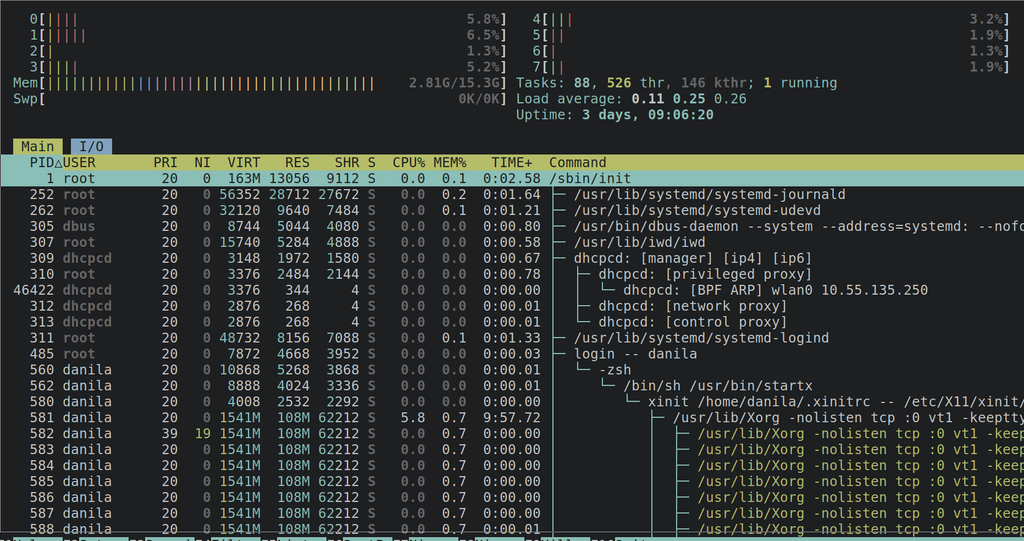

Можно поговорить подробнее

Есть файлик linux/sched.h. В этом файлике нам интересна структура `task_struct`

Кому интересно, можете посмотреть подробнее (ниже прям сверх-сокращенно)

```
struct task_struct {
    // эта фигня есть в адресном пространстве прцесса (с указателем на сюда)
    struct thread_info		thread_info;
    unsigned int			__state;
    /* что-то про priority... */
    int				prio;
    int				static_prio;
    int				normal_prio;

    /* Real parent process: */
    struct task_struct __rcu	*real_parent;  // родитель №1
    /* Recipient of SIGCHLD, wait4() reports: */
    struct task_struct __rcu	*parent;  // родитель №2

    pid_t				pid;
    unsigned int			policy;

    /*
     * Children/sibling form the list of natural children:
     */
    struct list_head		children;
    struct list_head		sibling;
};
```

### 5. Состояние процессора

Возможно вы заметили, как трудно было писать на ассемблере - приходилось постоянно думать, как ваша программа, находясь в оперативной памяти, мешает исполняться другим программам?)

Нет!)) Все было просто)))

Все благодаря виртуальной памяти и виртуальному процессу - каждый процесс думает, что он единственный запущенный процесс в системе!)

### 6. Адресное пространство и mmap

В принципе можно отнести к внутренним данным ядра

Но хочу выделить отдельно)

### 7. Потоки выполнения

В одном процессе может быть несколько потоков выполнения (та самая многопоточность)

Сложно сказать, что тут хранится *абстрактно*, но по факту тут стек + несколько регистров

### 8. Сегмент данных с глобальными переменными (section .data / .rodata / .bss)

Тут вроде все очевидно

### Вопросики?)

Процесс - программа в состоянии выполнения. Он включает в себя:

1. Исполняемый код (section .text)
2. Открытые файлы
3. Сигналы, ожидающие обработки
4. Внутренние данные ядра (об этом позже)
5. Состояние процессора (регистры)
6. Адресное пространство, в которое отображены один или несколько файлов (mmap)
7. Один или несколько потоков выполнения (на самом деле это стек)
8. Сегмент данных с глобальными переменными (section .data / .rodata / .bss)

## Нуууу раз все ок, тогда погнали в тяжелую артилерию)

**ВАЖНО** Тема холиварная и я с В.В. по разные стороны (хотя при этом друг с другом согласны) (I hope)

В Linux **!!!процесс = поток!!!**

В общем, в чем суть

У нас процесс описывается структуркой. Почти все поля которой (из пунктов 1 - 8) являются указателями

Внимание вопрос: что мешает этим указателям указывать на одно и то же место???

Внимание ответ: ничего не мешает)) Более того, оно часто так и происходит)

Кому интересно подробнее

- welcome to namespaces [Глубокое погружение в namespaces](https://habr.com/ru/post/458462/)
- welcome to cgroups [Мезанизмы контейнеризации: cgroups](https://habr.com/ru/company/selectel/blog/303190/)

### В двух словах, в чем суть

Было

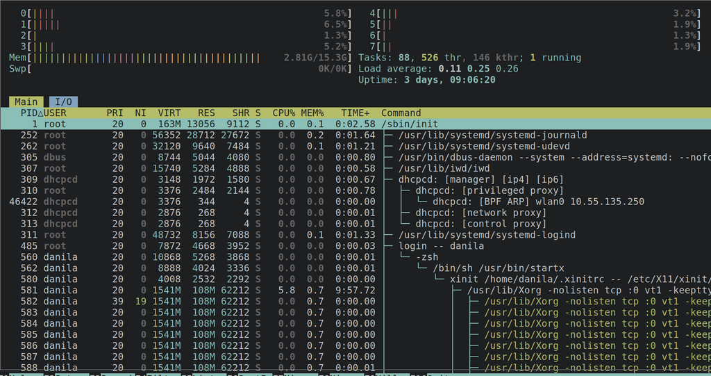

Стало

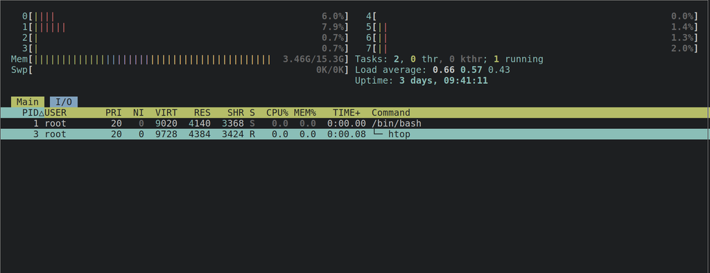

Заклинание:

```
[danila@archlinux ~]
$ sudo unshare --pid --fork --mount-proc /bin/bash
[root@archlinux danila]# ps -A  # Пытаемся вывести ВСЕ процессы в дереве (получаем только 2)
    PID TTY          TIME CMD
      1 pts/3    00:00:00 bash
      2 pts/3    00:00:00 ps
[root@archlinux danila]#
```

Так же рекомендую посмотреть на PID)))

Ну и чтоб совсем запутать (запускаем после заклинания)

```
#include <stdio.h>
#include <stdlib.h>
#include <unistd.h>
#include <pthread.h>

void *myThreadFun(void *vargp)
{
    printf("THREAD pid: %d\n", getpid());
    sleep(5);
    return NULL;
}

int main()
{
    printf("PROCESS pid: %d\n", getpid());
    pthread_t thread_id;
    pthread_create(&thread_id, NULL, myThreadFun, NULL);
    sleep(5);
    pthread_join(thread_id, NULL);
    exit(0);
}
```

```
[root@archlinux 08-fork]# ./a.out
PROCESS pid: 16
THREAD pid: 16
^Z
[1]+  Stopped                 ./a.out
[root@archlinux 08-fork]# ps -A -T
    PID    SPID TTY          TIME CMD
      1       1 pts/2    00:00:00 bash
     16      16 pts/2    00:00:00 a.out
     16      17 pts/2    00:00:00 a.out
     18      18 pts/2    00:00:00 ps
```

PID одинаковый, SPID разный (об этом чуть позже)

### Чуть подробнее, в чем суть

На каждый ресурс системы (память / дерево процессов / сигналы / открытые fd / ...) есть своя группа

Грубо говоря, кто в группе, тот и имеет доступ

**Процесс - тоже группа**

В этой группе даже потоки находятся

Поток может покинуть группу процесса, сменив указатель на другую структурку

Формально такой сущности как **процесс** в планировщике нет. И в ядре тоже нет.

Есть группа процесса. Которая ничем не отличается от других подобных групп

Планировщик ядра оперирует только потоками

## Детство, Отрочество, Юность... этапы жизни процесса

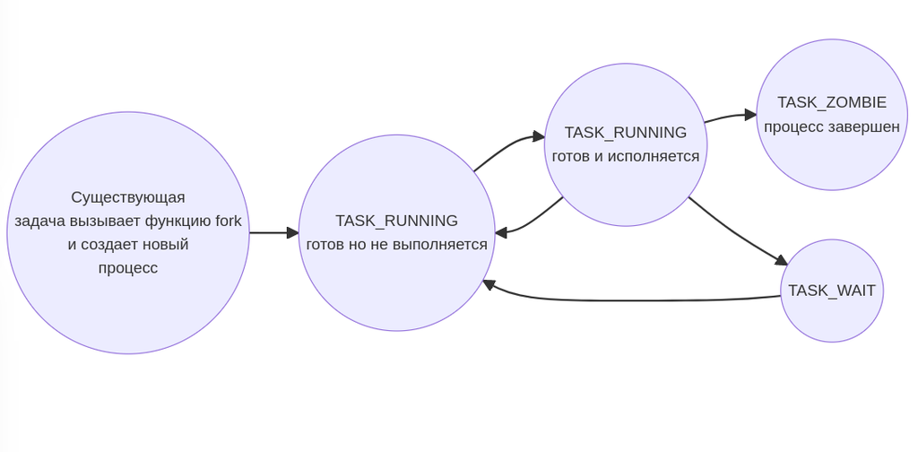

### Как создается процесс?

Если кратенько, то алгоритм следующий:

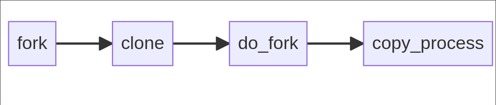

В первом приближении - мы копируем структурки (причем НЕрекурсивно)

Во втором приближении оказывается, что первого приближения достаточно

### Вопрос на понимание

Что из нижеперечисленного наследует дочерний процесс (и почему?)

1. Исполняемый код (section .text)
2. Открытые файлы
3. Сигналы, ожидающие обработки
4. Внутренние данные ядра
5. Состояние процессора (регистры)
6. Адресное пространство, в которое отображены один или несколько файлов (mmap)
7. Один или несколько потоков выполнения (на самом деле это стек)
8. Сегмент данных с глобальными переменными (section .data / .rodata / .bss)

### Клоны, близнецы, родители, убийства, зомби, удочерение, и прочая санта барбара... у нас тут весело

Короче

1. Когда один процесс порождает другой процесс, он клонирует себя (**fork** / **clone**)
2. Новый процесс называется **дочерним** (**child process**), старый процесс называется **родительским** (**parent process**)
3. Процессы, с общим родителям называются **siblings**
4. Мы можем послать сигнал, чтоб **kill** другой процесс (об этом - когда будут сигналы)
5. После смерти, процесс превращается в **zombie**. До тех пор, пока кто-то не дождется его **exit_success**
6. Если родительский процесс умер раньше, то дочерний процесс **удочеряет** другой процесс из родительской группы (или **init**)

## Время немножно покодить

[figure not shown]

### Основные инструменты - fork() + wait()

fork() - создает новый процесс

wait*() - ждет смерти одного или нескольких процессов

#### fork()

Принимает ничего

После вызова ОБА ПРОЦЕССА ПРОДОЛЖАЮТ ВЫПОЛНЕНИЕ С ТОГО ЖЕ МЕСТА

Возвращаемое значение:

- Родительский процесс получает PID дочернего
- Дочерний процесс получает 0

```python
#include <stdio.h>
#include <unistd.h>
```

```python
void do_smth() {
    pid_t pid = fork();

    if (pid == 0) {
        printf("I am child: %d\n", getpid());
        fflush(stdout);
        _exit(0);
    } else {
        printf("I am parent: %d\n my child pid is: %d\n", getpid(), pid);
        fflush(stdout);
    }
}

do_smth();
```

```
I am parent: 61985
 my child pid is: 62006
I am child: 62006
```

```
(void) nullptr
```

#### Ждем смерти детей (жуть...)

```
pid_t wait(int *wstatus);
pid_t waitpid(pid_t pid, int *wstatus, int options);
```

```python
#include <sys/wait.h>
```

```python
void long_work() {
    int sum = 0;
    for (int i = 0; i < 1000; ++i) {
        sum += i;
    }
}
```

```python
void spawn_then_wait() {
    pid_t pid = fork();

    if (pid == 0) {
        long_work();
        printf("Child death\n");
        fflush(stdout);
        _exit(0);
    } else {
        // ждем смерти...
        waitpid(pid, NULL, 0);
        printf("Parent death\n");
        fflush(stdout);
    }
}

spawn_then_wait();
```

```
Child death
Parent death
```

```
(void) nullptr
```

Поверьте мне, оно ждет)))

#### Получаем exit_success

```python
void do_tests() {
    pid_t pid;
    int status;

    pid = fork();
    if (pid == 0) _exit(0);
    status = 0;
    waitpid(pid, &status, 0);
    printf("exit_success: %d\n", WEXITSTATUS(status));


    pid = fork();
    if (pid == 0) _exit(123);
    status = 0;
    waitpid(pid, &status, 0);
    printf("exit_success: %d\n", WEXITSTATUS(status));


    pid = fork();
    if (pid == 0) _exit(123456);
    status = 0;
    waitpid(pid, &status, 0);
    printf("exit_success: %d\n", WEXITSTATUS(status));


    pid = fork();
    if (pid == 0) _exit(-10);
    status = 0;
    waitpid(pid, &status, 0);
    printf("exit_success: %d\n", WEXITSTATUS(status));
}

do_tests();
```

```
exit_success: 0
exit_success: 123
exit_success: 64
exit_success: 246
```

```
(void) nullptr
```

Что-то не то, да?)))

Some ideas?))

exit_success должен помещаться в 1 byte (unsigned char)

## Outro

Для закрепления можете ещё почиать

```
$ man 2 wait
```

А так всё))

Задачки всего 3

Все из них вы теперь можете решить))

## Thx!)

Всем спасибо, кто пришел!))